# Project3.1

# BIVARIATE ANALYSIS:-

**Talk about some relationships you obseved in this part of the investigation. How did the feature(s) of interest vary with other features in the dataset?**

By the above investigation there are some relations which can be said easily by above plots are sulphates,citric acid,alcohol which are directly proportional to the quality factor and inversly proportional to the chlorides and volatile acid.It had good scatter plots with different variables and there correlation coefficients.

**Did you observe any interesting relations between the other features(not the main feature(s) of interest)?**

Yes, There is a strong correalation between pH and the acidity of wine which come from fixed and volatile acidity, other one is the negative correlation with the alcohol level in the wine.

**What was the strongest relationship you found?**

Yes there is a strongest relation between alcohol and the quality of wine which is directly proportional and also density and alcohol are negativley correlated.

# MUTIVARIATE ANALYSIS :-

By seeing above analysis the variables alcohol,citric acid,volatile acid,chlorides and total sufur dioxide has great impact on deciding the good quality wine.

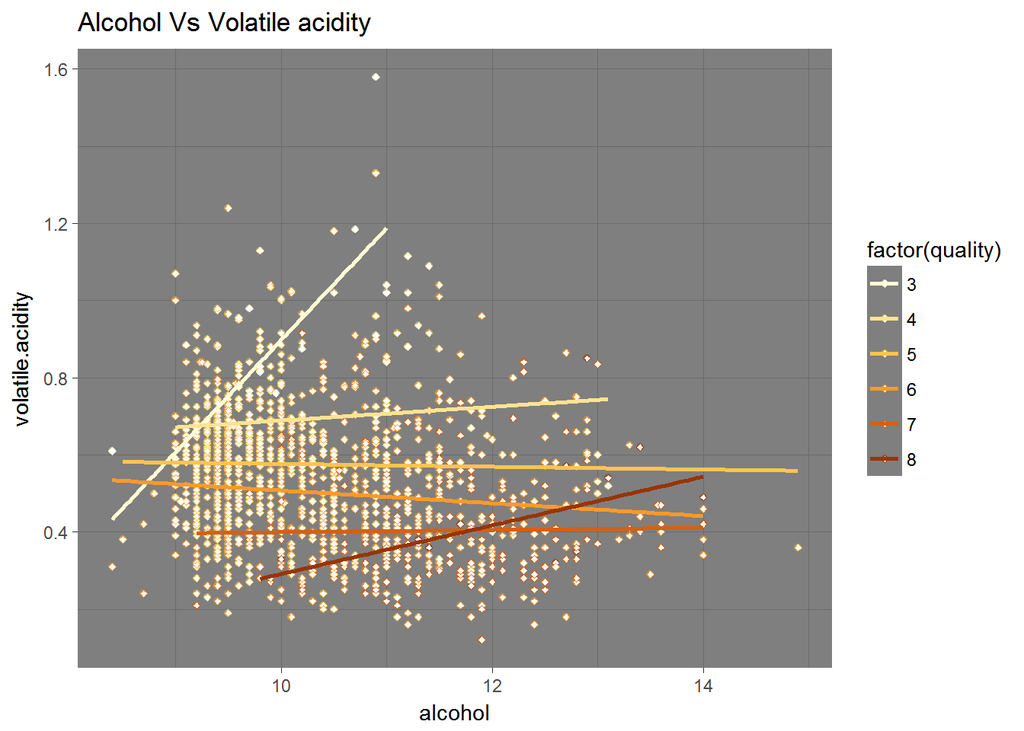

Here there is clear view about the volatile acidity and alcohol showing that the high qualtiy wines having little bit volatile acid with high alcohol level the brown line indicates positive ralation between them.

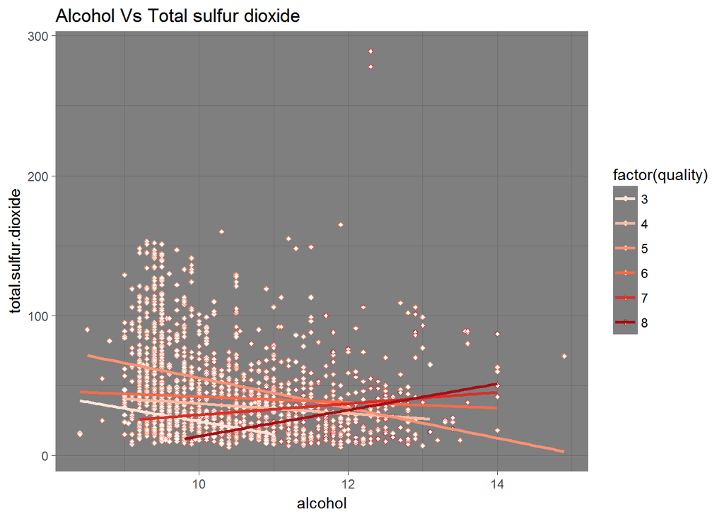

There is a simialr observation between alcohol and total sulfur dioxide which means with high alcohol and little bit of total sufu dioxide with possitive coefficient the red line showing the relation.

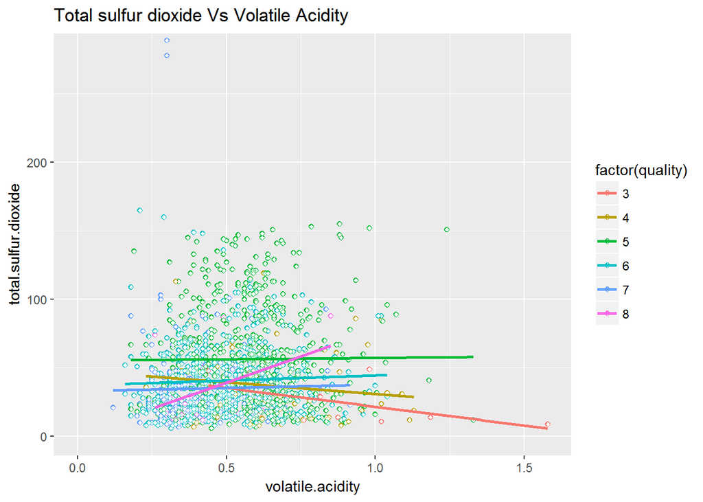

The above plot shows that the positive relation between total sulfur dioxide and vlatile acid for a good quality of a wine.

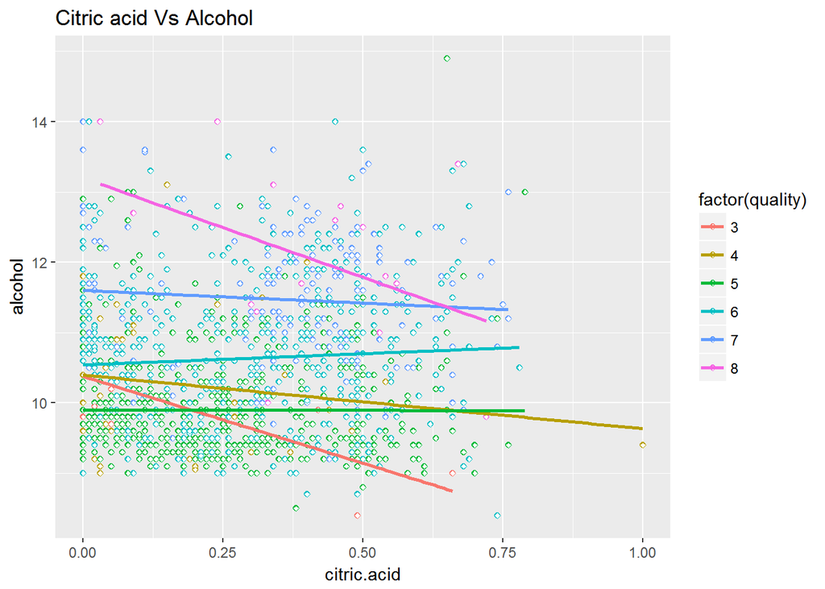

```
##
## Call:
## lm(formula = quality ~ alcohol + volatile.acidity + total.sulfur.dioxide +
##     citric.acid, data = wineQualityReds)
##
## Coefficients:
##          (Intercept)               alcohol      volatile.acidity
##             3.247836              0.301524             -1.306618
## total.sulfur.dioxide           citric.acid
##            -0.002014              0.105683
```

It is clear that the alcohol and the citric acid has the positive relation and the total sulfur dioxide and volatile acid has negative ralation.

# MULTIVARIATE ANALYSIS :-

**Talk about some of the relationships you observed in this part of the investigation.Were there features that strengthened each other in terms of looking at your feature(s) of interest?**

Here in the mutivariate plots there are few variables mostly concentrated making the quality as a factor because to find the good quality of wine.

Yes, there is a surprising thing here that the positive realtion between the quality and citric acid in bivariate analysis but here there is a negative relation found between other variables for a good quality of wine, so, we can predict that they use small quantities of citric acid for good quality wine.

**Did you create any models with your dataset? Discuss the strengths and limmitations of your model.**

Yes, created a linear model between between different variables which shown that the aicidity levels like volatile acid and sulfur dioxide are negatively related it means they are used in less quantites and alcohol & citric acid are in positive relations for a good quality wine, alcohol level is medium-high and the citric acid in low-high quantities.

# FINAL PLOTS :-

Here few main variables are taken from the analysis to examine the quality of wine.

## Final plot1:-

It is drawn between the acid level(sum of fixed and volatile acids) and pH level which used to calculate the acid quantity of wine.

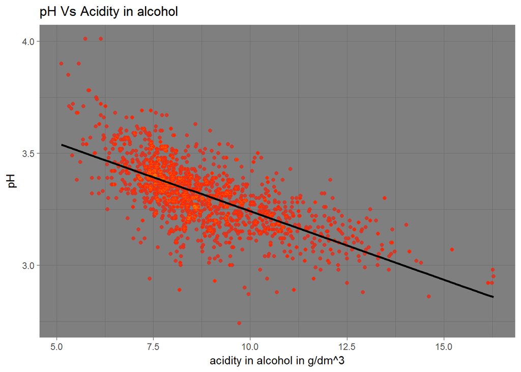

## Final Plot2:-

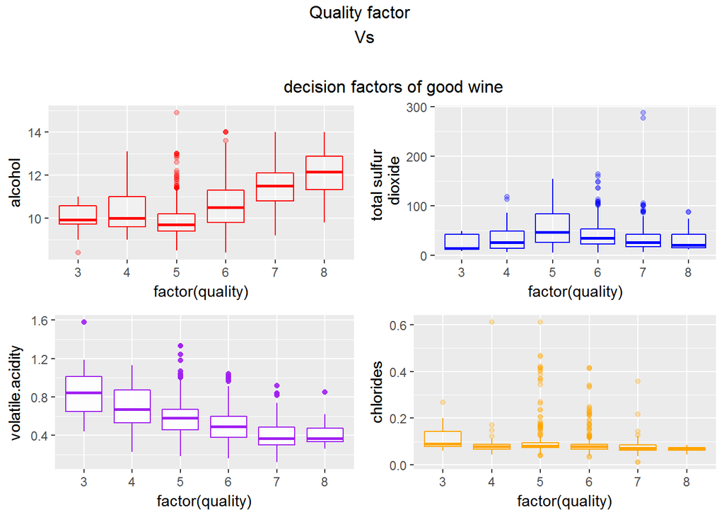

## Final Plot3:-

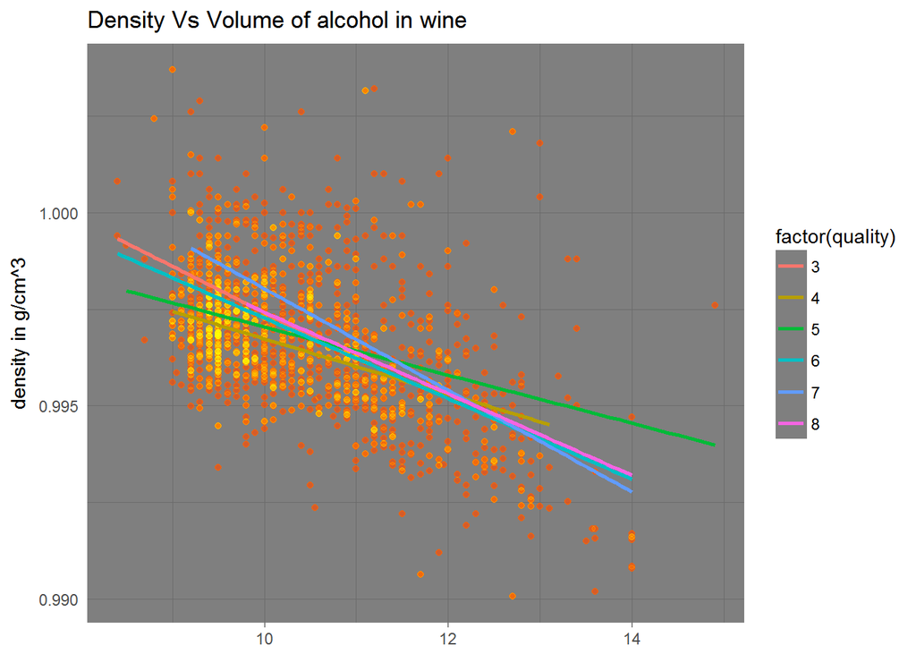

**Description:**

Here it is showing a relation between density and the volume alcohol in the wine.The density is high for the low volume alcohol. In the last the good quality wine has less density with high alcoholic nature.

# REFLECTION :-

The Quality Wine Reds contains the data of 13 different chemical variables wich are used in the 1599 observations which differnt properties. Basically when I started these project I surprised to see all the chemicals which are used to prepare wine and I only no that the good quality of wine has high concentraions of alcohol. And In my intial stages of project I felt difficulties to decide the variables which are used to find the good wine, after making a research of project using different anlysis like univariate,bi and multi varite plots I got a knowledge about the chemical properties and there reactions with the variables. I started plotting a scatter,box plots using different varibles in the data got conclusion about the main features of wine which discussed in the final plot section. And also learnt diffrent methods to find the correlation between the varibles and there purpose of use in the wine. In the last the good quality of wine consits high alcohol with low density and pH level which is noticed by the acidic nature of wine and also citric acid is used to keep the wine freshness in low levels.